# Data Science Class Project

Minyoung Do

3/1/2020

```r
gss2018 <- read_dta("GSS2018.dta") %>%
  # selecting demographics variables
  dplyr::select("id", "age", "sex", "race", "relig", "realrinc", "educ")

# transforming all categorical variables into factors for the meaningful level names
gss2018$sex <- as_factor(gss2018$sex, order = F)
gss2018$race <- as_factor(gss2018$race, order = F)
gss2018$relig <- as_factor(gss2018$relig, order = F)
```

## DEMOGRAPHICS OVERVIEW

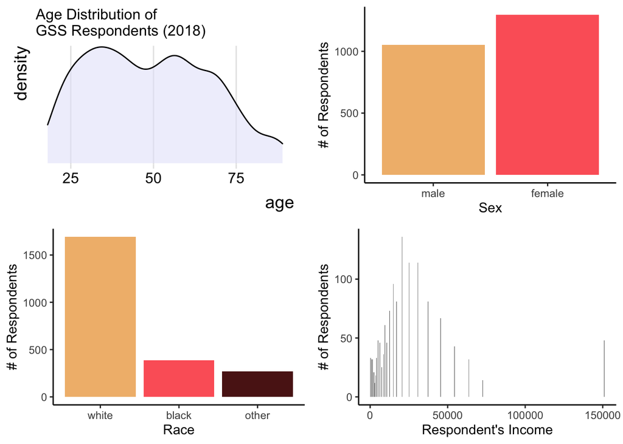

```r
age_plot <- gss2018 %>%
  dplyr::select("age") %>%
  drop_na() %>%
  ggplot(aes(x = age)) +
  theme_classic() +
  geom_density(fill = "lavender", alpha = .6, scale = 1.5) +
  scale_x_continuous(breaks = c(25, 50, 75)) +
  scale_y_discrete(expand = c(0.01, 0)) +
  labs(subtitle = "Age Distribution of\nGSS Respondents (2018)") +
  theme_ridges()

income_plot <- gss2018 %>%
  dplyr::select("realrinc") %>%
  filter(realrinc != "NA") %>%
    ggplot(aes(x = realrinc, fill = realrinc)) +
    geom_histogram(binwidth = 1, stat = "count") +
    theme_classic() +
    labs(x = "Respondent's Income", y = "# of Respondents")

sex_plot <- gss2018 %>%
  dplyr::select("sex") %>%
  drop_na() %>%
    ggplot(aes(x = sex, fill = sex)) +
    geom_histogram(binwidth = 1, stat = "count") +
    theme_classic() +
    labs(x = "Sex", y = "# of Respondents") +
  scale_fill_manual(name = "Answers", values = wes_palette(n = 2, name = "GrandBudapest1"))

race_plot <- gss2018 %>%
  dplyr::select("race") %>%
  drop_na() %>%
    ggplot(aes(x = race, fill = race)) +
    geom_histogram(binwidth = 1, stat = "count") +
    theme_classic() +
    labs(x = "Race", y = "# of Respondents") +
  scale_fill_manual(name = "Answers", values = wes_palette(n = 4, name = "GrandBudapest1"))

relig_plot <- gss2018 %>%
  dplyr::select("relig") %>%
  filter(relig != "NA", relig != "DK") %>%
  ggplot(aes(x = relig, fill = relig)) +
  geom_histogram(binwidth = 1, stat = "count") +
    theme_classic()

ggarrange(age_plot, sex_plot, race_plot, income_plot, legend = "none")
```

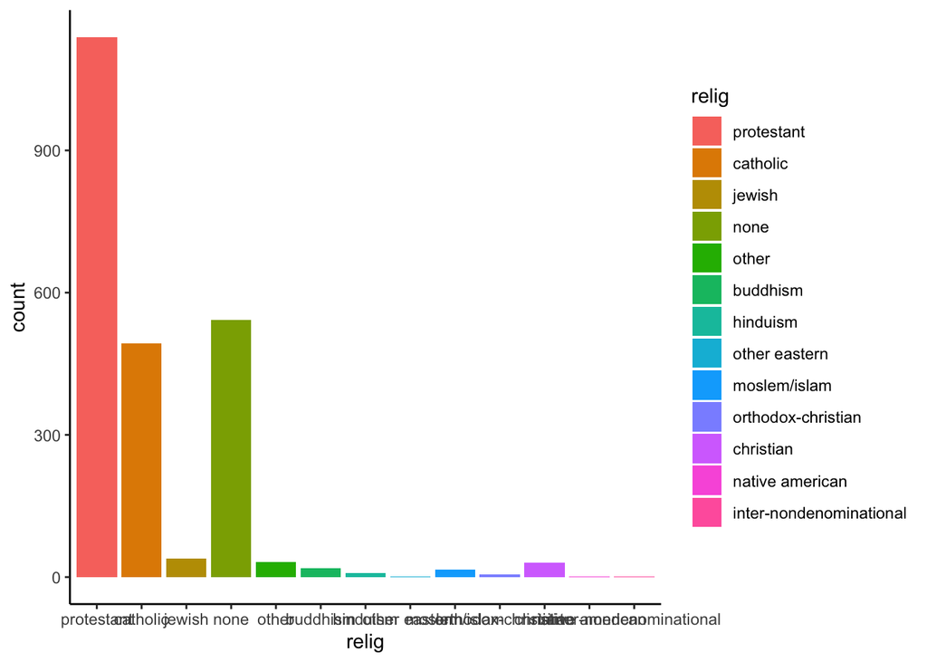

```r
relig_plot
```

Total respondents in the dataset: 2348

after dating cleaning process, the number of respondents is 518.

## Analysis

```r
gss_sex <- read_dta("GSS2018.dta") %>%
  dplyr::select("id", "age", "sex", "race", "relig", "realrinc",
         "educ", "rgroomed", "rlooks", "sexfreq",
         "relatsex", "quallife", "satlife", "satsoc") %>%
  drop_na()

gss_sex_factor <- read_dta("GSS2018.dta") %>%
  dplyr::select("id", "age", "sex", "race", "relig", "realrinc",
         "educ", "rgroomed", "rlooks", "sexfreq",
         "relatsex", "quallife", "satlife", "satsoc") %>%
  drop_na() %>%
  as_factor()
```

## A function to create plots

```r
gss_bar <- function(data, x) {
    ggplot(data, aes(x = .data[[x]])) +
    geom_bar(aes(fill = .data[[x]]), position = position_dodge()) +
    theme_light() +
    theme(plot.title = element_text(hjust = 0.5),
          plot.subtitle = element_text(hjust = 0.5),
          # intentionally removing x axis labels in order to avoid cramped-up unreadable labels
          axis.text.x = element_blank(),
          axis.ticks.x = element_blank())
  }
```

## Plots

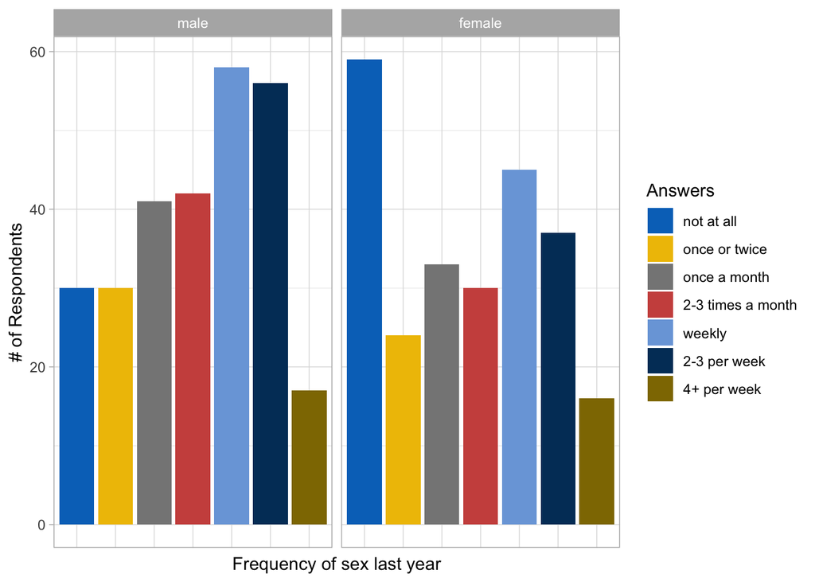

```r
# Sex frequency and sex
gss_bar(gss_sex_factor, "sexfreq") +
  labs(x = "Frequency of sex last year", y = "# of Respondents") +
  facet_wrap(~sex) +
  scale_fill_manual(name = "Answers", values = pal_jco()(7))
```

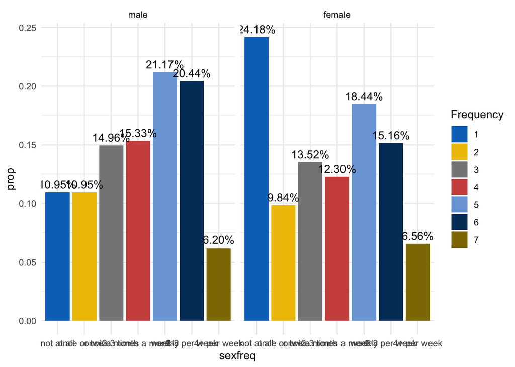

```r
# Proportion plot
ggplot(data = gss_sex_factor, aes(x = sexfreq, y = ..prop.., group = 1)) +
  geom_bar(aes(fill = factor(..x..)), stat = "count") +
  facet_wrap(~sex) +
  theme_minimal() +
  scale_fill_manual(name = "Frequency", values = pal_jco()(7)) +
  geom_text(aes(label = scales::percent(..prop..), y = ..prop.. ), stat= "count", vjust = -.5)
```

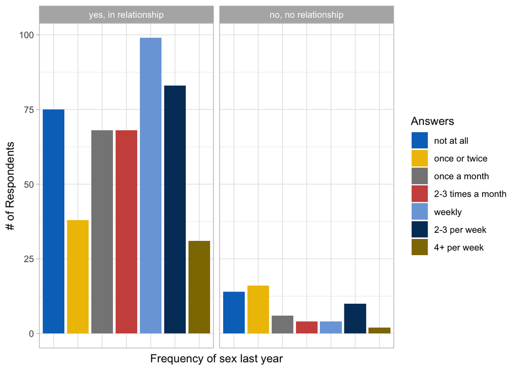

```r
# Sex frequency and relationship status
gss_bar(gss_sex_factor, "sexfreq") +
  labs(x = "Frequency of sex last year", y = "# of Respondents") +
  facet_wrap(~relatsex) +
  scale_fill_manual(name = "Answers", values = pal_jco()(7))
```

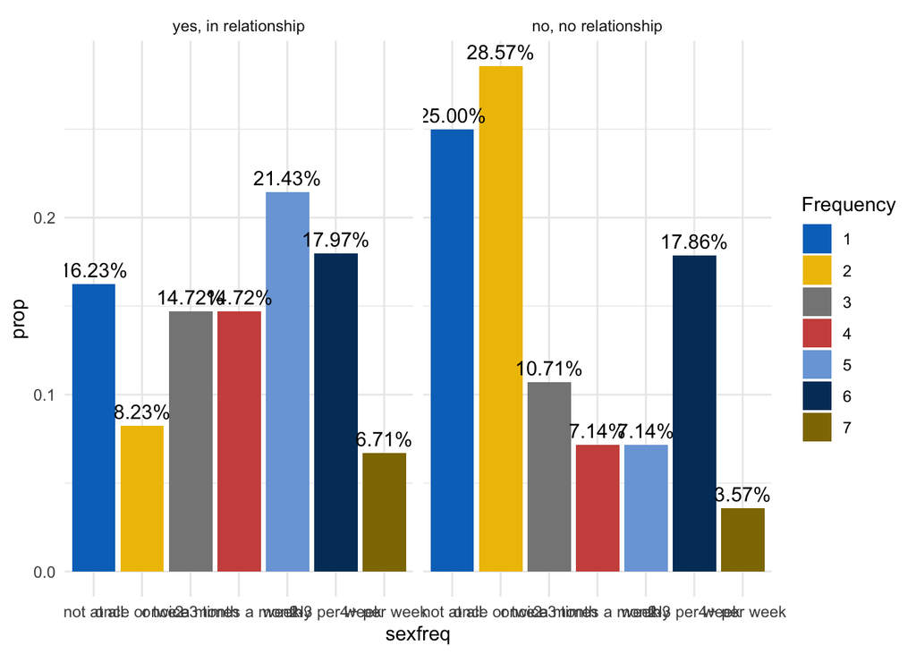

```r
# Proportion plot
ggplot(data = gss_sex_factor, aes(x = sexfreq, y = ..prop.., group = 1)) +
  geom_bar(aes(fill = factor(..x..)), stat = "count") +
  facet_wrap(~relatsex) +
  theme_minimal() +
  scale_fill_manual(name = "Frequency", values = pal_jco()(7)) +
  geom_text(aes(label = scales::percent(..prop..), y = ..prop.. ), stat= "count", vjust = -.5)
```

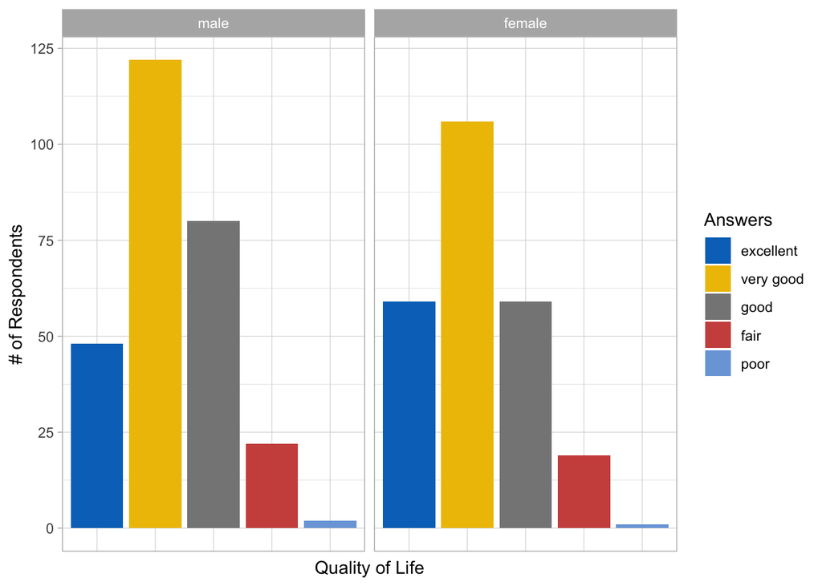

```r
# Sex frequency and sex
gss_bar(gss_sex_factor, "quallife") +
  labs(x = "Quality of Life", y = "# of Respondents") +
  facet_wrap(~sex) +
  scale_fill_manual(name = "Answers", values = pal_jco()(7))
```

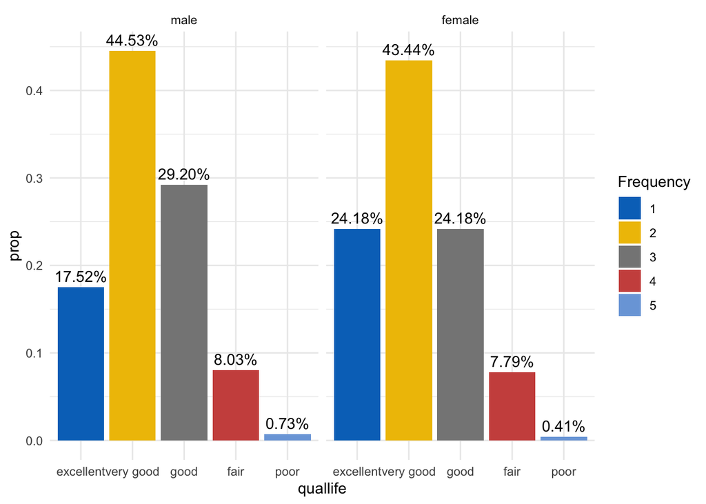

```r
ggplot(data = gss_sex_factor, aes(x = quallife, y = ..prop.., group = 1)) +
  geom_bar(aes(fill = factor(..x..)), stat = "count") +
  facet_wrap(~sex) +
  theme_minimal() +
  scale_fill_manual(name = "Frequency", values = pal_jco()(7)) +
  geom_text(aes(label = scales::percent(..prop..), y = ..prop.. ), stat= "count", vjust = -.5)
```

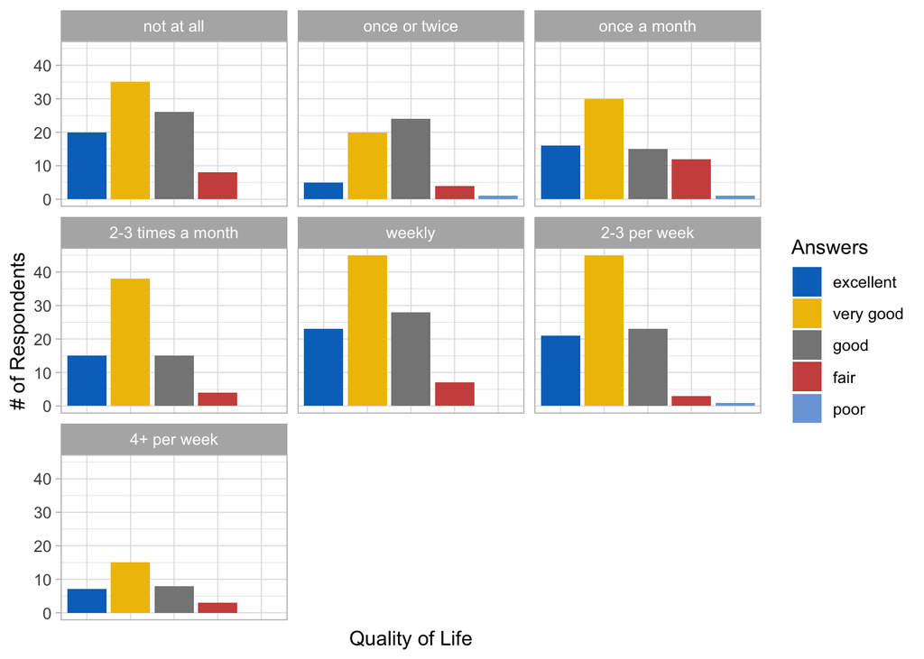

```r
# Sex frequency and relationship status
gss_bar(gss_sex_factor, "quallife") +
  labs(x = "Quality of Life", y = "# of Respondents") +
  facet_wrap(~sexfreq) +
  scale_fill_manual(name = "Answers", values = pal_jco()(7))
```

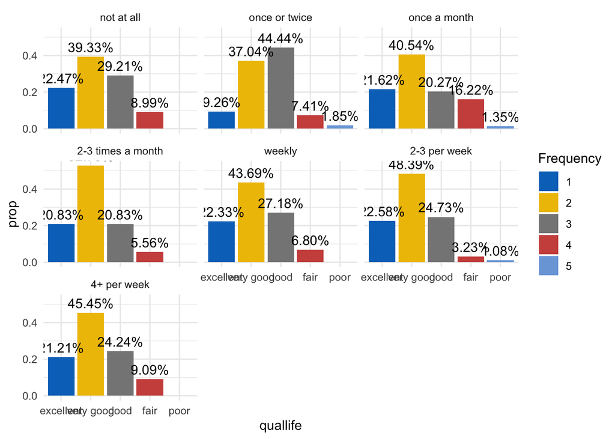

```r
# Proportion plot
ggplot(data = gss_sex_factor, aes(x = quallife, y = ..prop.., group = 1)) +
  geom_bar(aes(fill = factor(..x..)), stat = "count") +
  facet_wrap(~sexfreq) +
  theme_minimal() +
  scale_fill_manual(name = "Frequency", values = pal_jco()(7)) +
  geom_text(aes(label = scales::percent(..prop..), y = ..prop.. ), stat= "count", vjust = -.5)
```

```r
# proportions of rows, columns, totals, chi-square
CrossTable(gss_sex$sexfreq, gss_sex$quallife,
           expected = TRUE)
```

```
##
##
##    Cell Contents
## |-------------------------|
## |                       N |
## |              Expected N |
## | Chi-square contribution |
## |           N / Row Total |
## |           N / Col Total |
## |         N / Table Total |
## |-------------------------|
##
##
## Total Observations in Table:  518
##
##
##                 | gss_sex$quallife
## gss_sex$sexfreq |         1 |         2 |         3 |         4 |         5 | Row Total |
## ----------------|-----------|-----------|-----------|-----------|-----------|-----------|
##               0 |        20 |        35 |        26 |         8 |         0 |        89 |
##                 |    18.384 |    39.174 |    23.882 |     7.044 |     0.515 |           |
##                 |     0.142 |     0.445 |     0.188 |     0.130 |     0.515 |           |
##                 |     0.225 |     0.393 |     0.292 |     0.090 |     0.000 |     0.172 |
##                 |     0.187 |     0.154 |     0.187 |     0.195 |     0.000 |           |
##                 |     0.039 |     0.068 |     0.050 |     0.015 |     0.000 |           |
## ----------------|-----------|-----------|-----------|-----------|-----------|-----------|
##               1 |         5 |        20 |        24 |         4 |         1 |        54 |
##                 |    11.154 |    23.768 |    14.490 |     4.274 |     0.313 |           |
##                 |     3.396 |     0.597 |     6.241 |     0.018 |     1.510 |           |
##                 |     0.093 |     0.370 |     0.444 |     0.074 |     0.019 |     0.104 |
##                 |     0.047 |     0.088 |     0.173 |     0.098 |     0.333 |           |
##                 |     0.010 |     0.039 |     0.046 |     0.008 |     0.002 |           |
## ----------------|-----------|-----------|-----------|-----------|-----------|-----------|
##               2 |        16 |        30 |        15 |        12 |         1 |        74 |
##                 |    15.286 |    32.571 |    19.857 |     5.857 |     0.429 |           |
##                 |     0.033 |     0.203 |     1.188 |     6.443 |     0.762 |           |
##                 |     0.216 |     0.405 |     0.203 |     0.162 |     0.014 |     0.143 |
##                 |     0.150 |     0.132 |     0.108 |     0.293 |     0.333 |           |
##                 |     0.031 |     0.058 |     0.029 |     0.023 |     0.002 |           |
## ----------------|-----------|-----------|-----------|-----------|-----------|-----------|
```

[output cut: 27 more lines]

```
## ----------------|-----------|-----------|-----------|-----------|-----------|-----------|
##    Column Total |       107 |       228 |       139 |        41 |         3 |       518 |
##                 |     0.207 |     0.440 |     0.268 |     0.079 |     0.006 |           |
## ----------------|-----------|-----------|-----------|-----------|-----------|-----------|
##
##
## Statistics for All Table Factors
##
##
## Pearson's Chi-squared test
## ------------------------------------------------------------
## Chi^2 =  29.91782     d.f. =  24     p =  0.1874904
##
##
##
```

```r
# contingency table & chi-square tests
a <- table(gss_sex$sexfreq, gss_sex$sex)[1:7, ]
chisq.test(a)
```

```
##
##  Pearson's Chi-squared test
##
## data:  a
## X-squared = 16.853, df = 6, p-value = 0.00984
```

```r
b <- table(gss_sex$rgroomed, gss_sex$sex)[1:5, ]
chisq.test(b)
```

```
##
##  Pearson's Chi-squared test
##
## data:  b
## X-squared = 9.8749, df = 4, p-value = 0.04259
```

```r
c <- table(gss_sex$rlooks, gss_sex$sex)[1:5, ]
chisq.test(c)
```

```
##
##  Pearson's Chi-squared test
##
## data:  c
## X-squared = 4.3277, df = 4, p-value = 0.3635
```

```r
d <- table(gss_sex$relatsex, gss_sex$sex)[1:2, ]
chisq.test(d)
```

```
##
##  Pearson's Chi-squared test with Yates' continuity correction
##
## data:  d
## X-squared = 6.3341, df = 1, p-value = 0.01184
```

```r
e <- table(gss_sex$sexfreq, gss_sex$quallife)[1:7, 1:5]
chisq.test(e)
```

```
##
##  Pearson's Chi-squared test
##
## data:  e
## X-squared = 29.918, df = 24, p-value = 0.1875
```

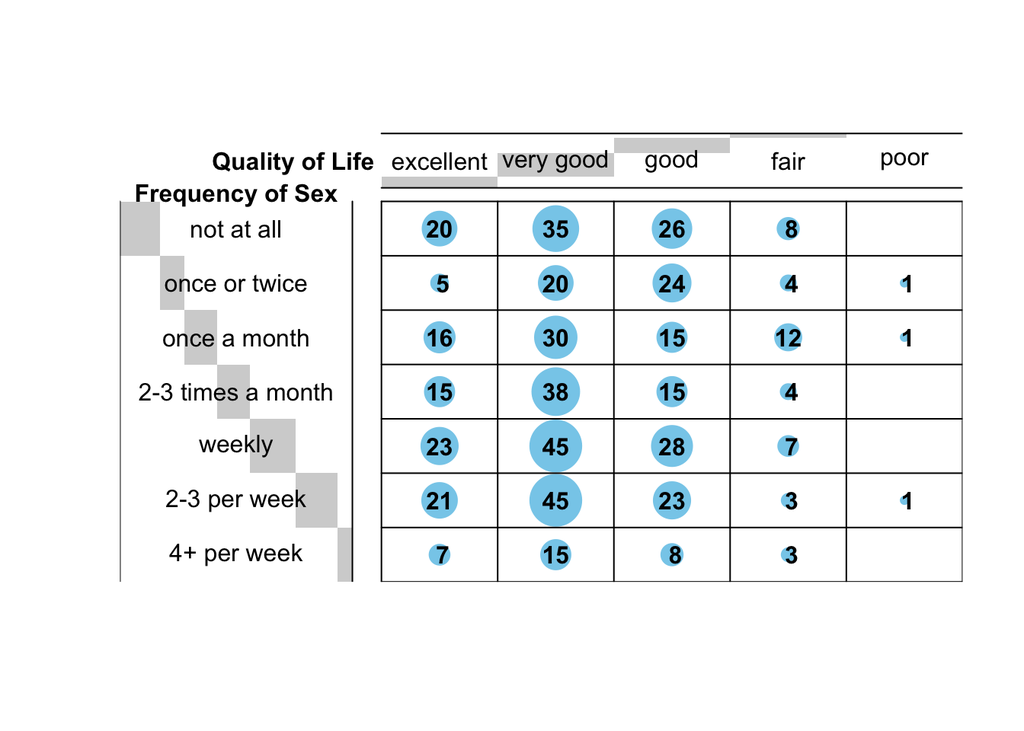

```r
plot_e <- table(gss_sex_factor$sexfreq, gss_sex_factor$quallife)[1:7, 1:5]

balloonplot(t(plot_e), main = "", xlab = "Quality of Life", ylab = "Frequency of Sex",
            label = T, show.margins = F)
```

```r
# contingency table
e <- table(gss_sex$sexfreq, gss_sex$quallife)[1:7, 1:5]
# running chi-square test
chisq.test(e)
```

```
##
##  Pearson's Chi-squared test
##
## data:  e
## X-squared = 29.918, df = 24, p-value = 0.1875
```

```r
# effect size
cramerV(e)
```

```
## Cramer V
##   0.1202
```

```r
# running power analysis with Cramer's V effect size = 0.1202
pwr::pwr.chisq.test(N = 518, df = 4, w = 0.1202, sig.level = 0.95)
```

```
##
##      Chi squared power calculation
##
##               w = 0.1202
##               N = 518
##              df = 4
##       sig.level = 0.95
##           power = 0.9982144
##
## NOTE: N is the number of observations
```

I apply the `chisq.test` function to the contingency table, and found the p-value to be 0.1875. As the p-value 0.1875 is greater than the .05 significance level, we can’t reject the null hypothesis that the frequency of sex is independent of the quality of life.

When power is high, smaller risk of committing Type 2 error; Since power is 1 - type 2 error. The data provides convincing evidence that there is a difference in the frequency of sexual intercourse last year between male and female who are 18 or over.